# Math 189: Principal Components Analysis II

## How to Find Principal Components?

- The principal directions can be found by computing the eigenvalues and eigenvectors of the covariance matrix ${\mathbf \Sigma}$.
- Let $\lambda_1, \ldots, \lambda_p$ denote the eigenvalues of ${\mathbf \Sigma}$ in descending order, i.e.
  $$\lambda_1 \geq \lambda_2 \geq \ldots \geq \lambda_p.$$
- Let $\underline{e}_1, \ldots, \underline{e}_p$ be the corresponding eigenvectors (with unit length):
  $${\mathbf \Sigma} \, \underline{e}_j = \lambda_j \, \underline{e}_j$$
  for $j = 1, \ldots, p$.
- In fact, the $j$th eigenvector will serve as the $j$th principal direction!
1. $\underline{e}_j^{\prime} \underline{e}_j = 1$ and $\underline{e}_j^{\prime} \underline{e}_k = 0$ for $k \neq j$, due to orthogonality of eigenvectors (if eigenvalues are distinct).
2. Because
   $$\mbox{Var} [ y_j] = \underline{e}_j^{\prime} {\mathbf \Sigma} \underline{e}_j
   = \lambda_j \underline{e}_j^{\prime} \underline{e}_j = \lambda_j,$$
   we see that $\mbox{Var} [ y_1] \geq \mbox{Var} [ y_2] \geq \ldots \geq \mbox{Var} [ y_p]$.
3. Also for $j \neq k$
   $$\mbox{Cov} [ y_j, y_k] = \underline{e}_j^{\prime} {\mathbf \Sigma} \underline{e}_k
   = \lambda_k \underline{e}_j^{\prime} \underline{e}_k = 0$$
   so the new variables $y_1, \ldots, y_p$ are uncorrelated.

## Spectral Decomposition Theorem

- The covariance matrix is symmetric and positive semi-definite. It admits a spectral decomposition:
  $${\mathbf \Sigma} = \sum_{j=1}^p \lambda_j \underline{e}_j \underline{e}_j^{\prime}.$$
- The spectral decomposition states that the linear space spanned by the $p$ features can be fully explained by the $p$ orthogonal directions (the principal vectors).
- This decomposition suggests that we can approximate ${\mathbf \Sigma}$ by its first $k$ eigenvectors:
  $${\mathbf \Sigma} \approx \sum_{j=1}^k \lambda_j \underline{e}_j \underline{e}_j^{\prime},$$
  for some $k < p$.
- This approximation is useful when $\lambda_{k+1}, \ldots, \lambda_p$ are small. In other words,
  $${\mathbf \Sigma} - \sum_{j=1}^k \lambda_j \underline{e}_j \underline{e}_j^{\prime}=
  \sum_{j=k+1}^p \lambda_j \underline{e}_j \underline{e}_j^{\prime}$$
  is negligible.

## Uniqueness of the Principal Components

- Each principal component loading vector is unique, up to a sign flip. This means that two different software packages will yield the same principal component loading vectors up to signs.
- The signs may differ because each principal component loading vector specifies a direction in ${\mathbf R}^p$: flipping the sign does not affect the amount of variability contained in each PC.

## How Much Information Do We Lose?

- The total variation of $\underline{X}$ is the trace of its covariance matrix ${\mathbf \Sigma}$. This is also the sum of all the eigenvalues:
  $$\mbox{tr} {\bf \Sigma} = \sum_{j=1}^p \lambda_j.$$
- The proportion of variation explained by the $k$th principal component is
  $$\frac{ \lambda_k}{ \sum_{j=1}^p \lambda_j}$$
- The proportion of variation explained by the first $k$ principal components is
  $$\frac{ \sum_{j=1}^k \lambda_j}{ \sum_{j=1}^p \lambda_j}.$$
- Naturally, if the proportion of variation explained by the first $k$ principal components is large, then not much information is lost by considering only the first $k$ principal components.

## Choose the Number of Principal Components

- To reduce the dimensionality, we only retain the first $k$ principal components.
- Here we need to balance two conflicting purposes:
1. To obtain the simplest possible interpretation, we want $k$ to be as small as possible. If we can explain most of the variation by just looking at the first few principal components, then it would give us a simpler description of the data.
2. To reduce loss of information, we want the proportion of variation explained by the first $k$ principal components to be large (ideally close to 1):
   $$\frac{ \sum_{j=1}^k \lambda_j}{ \sum_{j=1}^p \lambda_j} \approx 1$$

## Estimate Principal Components From a Sample

- Suppose we observe a sample $\underline{x}_1, \ldots, \underline{x}_n$ of $p$ features.
- The principle components can be estimated via the following steps:
1. Standardize each variable to have mean 0 and standard deviation 1.
2. Calculate the sample covariance matrix
   $${\mathbf S} = \frac{1}{n-1} \sum_{i=1}^n ( \underline{x}_i - \overline{\underline{x}})
   {( \underline{x}_i - \overline{\underline{x}})}^{\prime}.$$
3. Calculate eigenvalues and eigenvectors of ${\mathbf S}$. Let $\hat{\lambda}_1, \ldots, \hat{\lambda}_p$ denote the eigenvalues of ${\mathbf S}$ in descending order, and let $\hat{\underline{e}}_1, \ldots, \hat{\underline{e}}_p$ be the corresponding eigenvectors.
4. The estimated principal components are
   $$\hat{y}_{i1} = \hat{\underline{e}}_1^{\prime} \underline{x}_i,
   \ldots, \hat{y}_{ip} = \hat{\underline{e}}_p^{\prime} \underline{x}_i.$$

## Example: Violent Crime Rates by US State

- This dataset contains records of arrests per 100,000 residents for assault, murder, and rape in each of the 50 US states in 1973. The dataset also includes the percent of the population living in urban areas.
- The dataset contains 50 observations of the following four variables:
1. Murder: number of murder arrests per 100,000 residents.
2. Assault: number of assault arrests per 100,000 residents.
3. Rape: number of rape arrests per 100,000 residents.
4. UrbanPop: percentage of urban population.

### A Peek at the Dataset

- First let’s take a quick look at the dataset along with some descriptive statistics.

```r
data(USArrests)
head(USArrests)
```

```
##            Murder Assault UrbanPop Rape
## Alabama      13.2     236       58 21.2
## Alaska       10.0     263       48 44.5
## Arizona       8.1     294       80 31.0
## Arkansas      8.8     190       50 19.5
## California    9.0     276       91 40.6
## Colorado      7.9     204       78 38.7
```

```r
states <- row.names(USArrests)
out1 <- rbind(apply(USArrests, 2, mean),apply(USArrests, 2, var))
rownames(out1) <- c("Sample Mean","Sample Variance")
out1
```

```
##                   Murder  Assault UrbanPop     Rape
## Sample Mean      7.78800  170.760  65.5400 21.23200
## Sample Variance 18.97047 6945.166 209.5188 87.72916
```

### Principle Component Analysis Results

- We first standardize each variable to have mean 0 and standard deviation 1. Then we apply PCA to the standardized data.
- All four eigenvalues and their corresponding eigenvectors are listed below.
- We also report the proportion of total variance explained by each PC and the cumulative proportion explained.

```r
pca_result <- eigen(cor(USArrests))
pca_var <- pca_result$values
pve <- pca_var/sum(pca_var)
out2 <- cbind(pca_var,pve,cumsum(pve))
colnames(out2) <- c("Eigenvalue","Proportion","Cumulative")
rownames(out2) <- c("PC1","PC2","PC3","PC4")
out2
```

```
##     Eigenvalue Proportion Cumulative
## PC1  2.4802416 0.62006039  0.6200604
## PC2  0.9897652 0.24744129  0.8675017
## PC3  0.3565632 0.08914080  0.9566425
## PC4  0.1734301 0.04335752  1.0000000
```

- We can get the transformed data as well!

```r
z <- (t(USArrests) - out1[1,])/sqrt(out1[2,])
e_mat <- pca_result$vectors
y <- t(e_mat) %*% z
y[1:2,]
```

```
##         Alabama    Alaska    Arizona  Arkansas California   Colorado
## [1,] -0.9756604 -1.930538 -1.7454429 0.1399989  -2.498613 -1.4993407
## [2,]  1.1220012  1.062427 -0.7384595 1.1085423  -1.527427 -0.9776297
##      Connecticut    Delaware     Florida   Georgia     Hawaii     Idaho
## [1,]    1.344992 -0.04722981 -2.98275967 -1.622807  0.9034845 1.6233190
## [2,]   -1.077984 -0.32208890  0.03883425  1.266088 -1.5546761 0.2088525
##        Illinois    Indiana       Iowa     Kansas  Kentucky  Louisiana     Maine
## [1,] -1.3650520  0.5003812  2.2309958  0.7888721 0.7433126 -1.5490908 2.3727401
## [2,] -0.6749883 -0.1500393 -0.1030083 -0.2674494 0.9488075  0.8623001 0.3726087
##       Maryland Massachusetts  Michigan  Minnesota Mississippi   Missouri
## [1,] -1.745647     0.4812801 -2.087250  1.6756695  -0.9864792 -0.6897843
## [2,]  0.423357    -1.4596771 -0.153835 -0.6259067   2.3697371 -0.2607079
##        Montana   Nebraska    Nevada New Hampshire New Jersey New Mexico
## [1,] 1.1735375  1.2529163 -2.845505    2.35995585 -0.1797413 -1.9601235
## [2,] 0.5314785 -0.1920044 -0.767805   -0.01790055 -1.4349374  0.1414131
##        New York North Carolina North Dakota       Ohio   Oklahoma      Oregon
## [1,] -1.6656666      -1.112088    2.9621522  0.2236944  0.3086493 -0.05852787
## [2,] -0.8149107       2.205611    0.5930974 -0.7347784 -0.2849611 -0.53596999
##      Pennsylvania Rhode Island South Carolina South Dakota  Tennessee
## [1,]    0.8794868    0.8550907      -1.307450    1.9677967 -0.9896938
## [2,]   -0.5653605   -1.4769833       1.913973    0.8150682  0.8516053
##           Texas       Utah  Vermont  Virginia Washington West Virginia
## [1,] -1.3415184  0.5450318 2.773256 0.0953667  0.2147234      2.087393
## [2,] -0.4083352 -1.4567152 1.388194 0.1977278 -0.9603739      1.410526
##       Wisconsin   Wyoming
## [1,]  2.0588120 0.6231006
## [2,] -0.6051251 0.3177866
```

- Fancy with *prcomp*:

```r
#"scale=True" means the data are standardized first
pca_result <- prcomp(USArrests, scale = TRUE)
pca_var <- pca_result$sdev^2
pve <- pca_var/sum(pca_var)
out2 <- cbind(pca_var,pve,cumsum(pve))
colnames(out2) <- c("Eigenvalue","Proportion","Cumulative")
rownames(out2) <- c("PC1","PC2","PC3","PC4")
out2
```

```
##     Eigenvalue Proportion Cumulative
## PC1  2.4802416 0.62006039  0.6200604
## PC2  0.9897652 0.24744129  0.8675017
## PC3  0.3565632 0.08914080  0.9566425
## PC4  0.1734301 0.04335752  1.0000000
```

### Scree Plot and Cumulative Proportion Plot

- We draw the so-called scree plot to visualize the proportion of total variance explained by each PC. Also, we can visualize the cumulative proportion explained by first $k$ PCs.

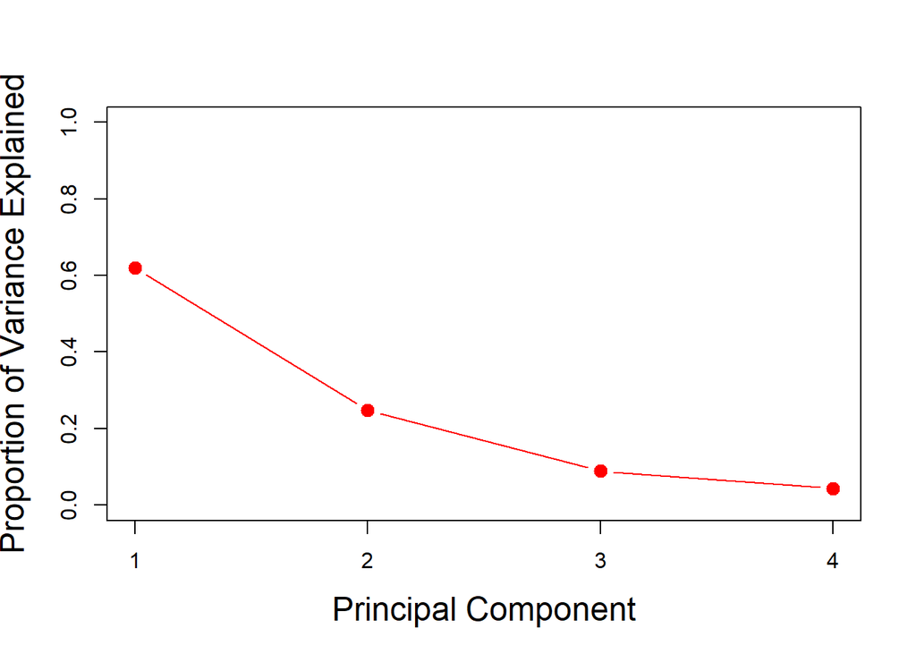

```r
#Scree plot
plot(pve, xlab=" Principal Component ",
  ylab=" Proportion of Variance Explained ",
  ylim=c(0,1), xaxt="n" ,type='b', col="red",
  cex=2,pch=20, cex.lab=1.5)
axis(1, at=c(1,2,3,4),labels=c(1,2,3,4))
```

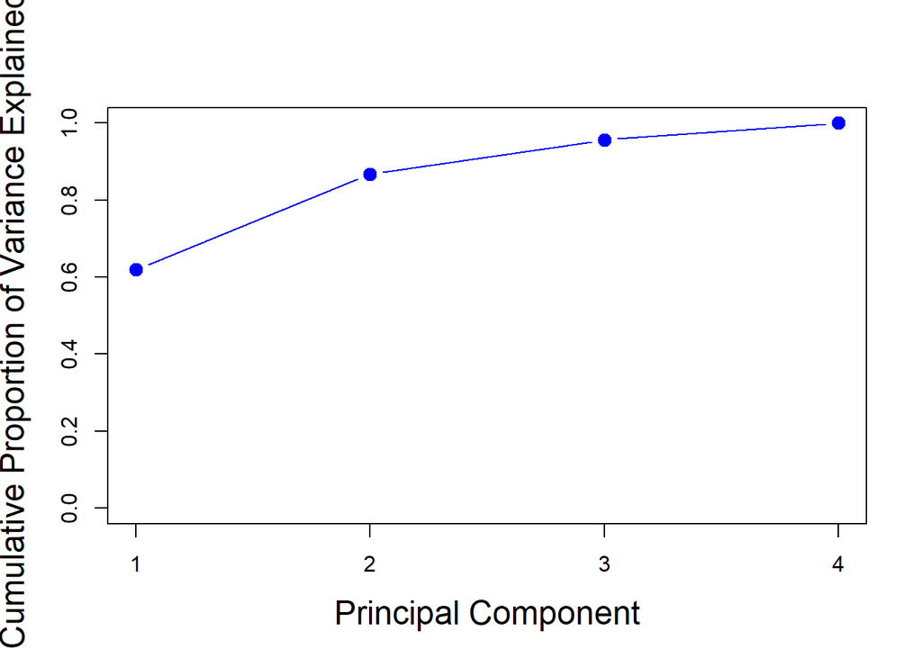

```r
#Cumulative proportion plot
plot(cumsum(pve), xlab=" Principal Component ",
  ylab ="Cumulative Proportion of Variance Explained ",
  ylim=c(0,1) , xaxt="n", type='b', col="blue",
  cex=2, pch=20, cex.lab=1.5)
axis(1, at=c(1,2,3,4),labels=c(1,2,3,4))
```

### Visualize the Dataset by First Two PCs

- As a dimension reduction tool, PCA allows us to visualize multivariate data through a lower dimensional projection.
- Here, we plot the data projected onto the first two PCs.

```r
library(ggfortify)
```

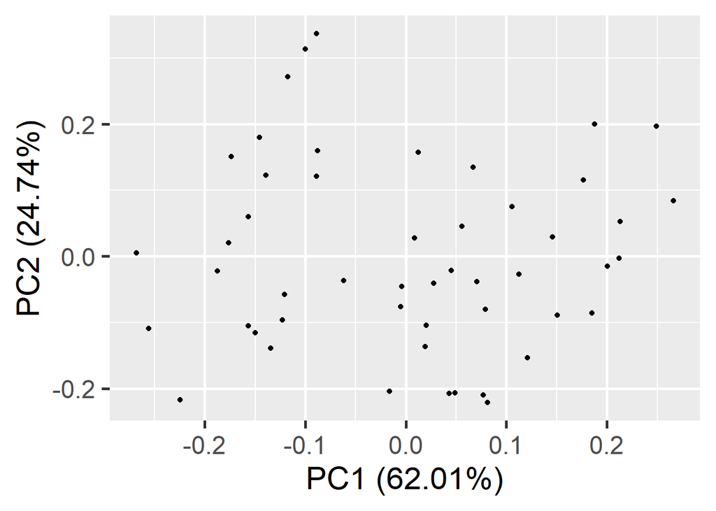

```r
plot_0 <- autoplot(pca_result, data = USArrests, colour = 'black')
plot_0 + theme_grey(base_size = 22)
```

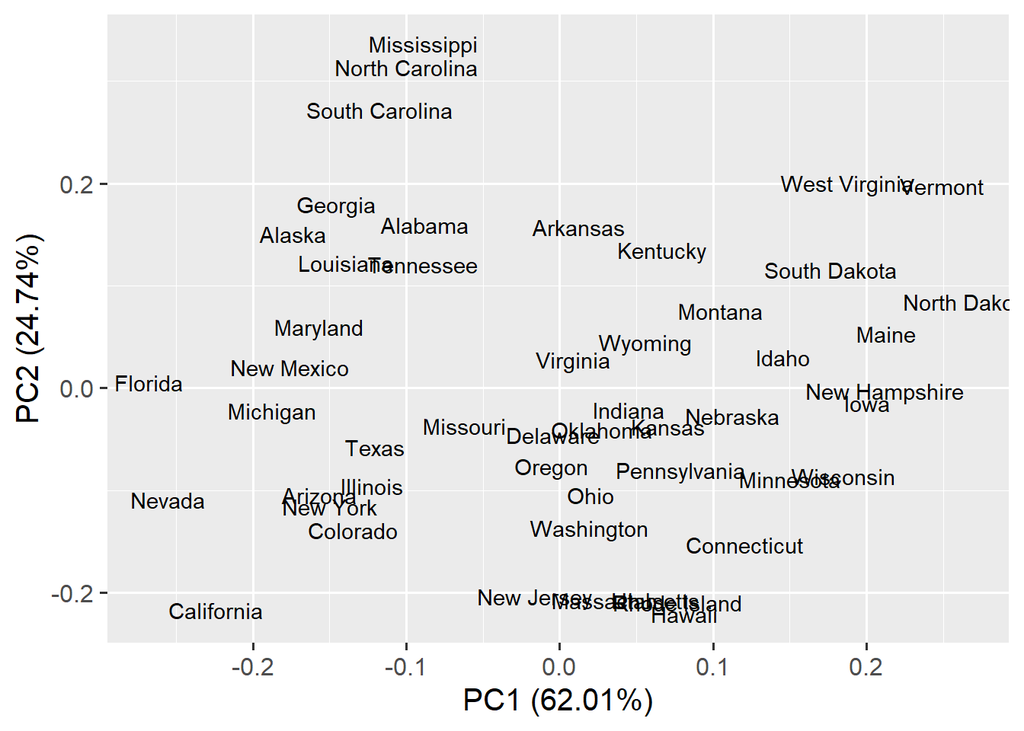

```r
plot_1 <- autoplot(pca_result, data = USArrests, color = 'steelblue',
                label=TRUE, shape=FALSE, size=2)
plot_1 + theme_grey(base_size = 15)
```

### Compare with Pairwise Scatterplot

- Pairwise scatterplot consists of $p(p-1)/2$ independent scatterplots.
- Pairwise scatterplot views only marginal dependence rather than joint effect.

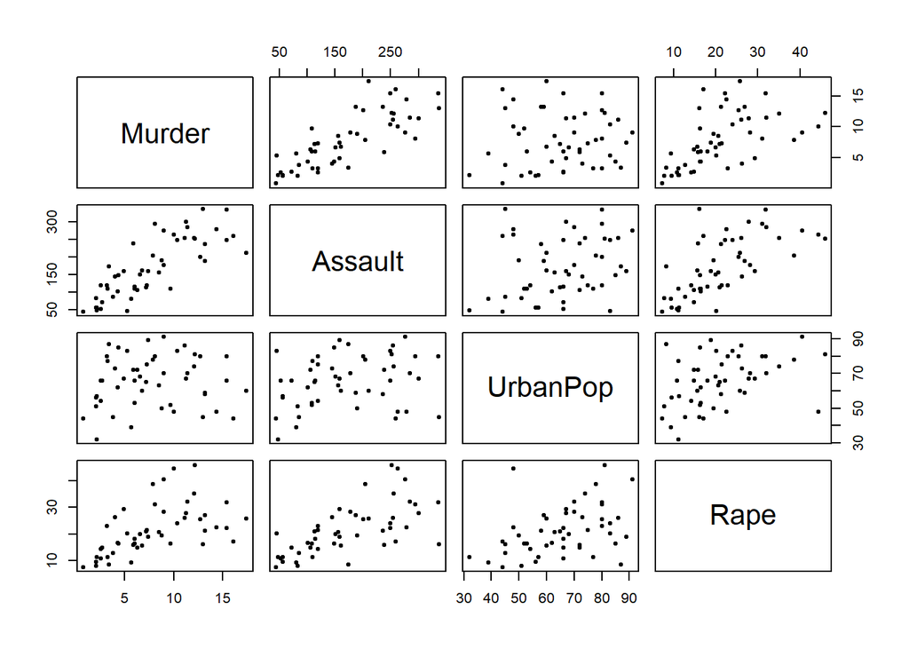

```r
pairs(USArrests, pch=20)
```

### Interpret Principal Components

- The eigenvectors are used as the estimated principal component loading vectors.
- These loading vectors show coefficients of each principal component as a linear combination of variables.
- The calculated principal component coefficients are listed as follows.

```r
t(pca_result$rotation)
```

```
##         Murder    Assault   UrbanPop        Rape
## PC1 -0.5358995 -0.5831836 -0.2781909 -0.54343209
## PC2  0.4181809  0.1879856 -0.8728062 -0.16731864
## PC3 -0.3412327 -0.2681484 -0.3780158  0.81777791
## PC4  0.6492278 -0.7434075  0.1338777  0.08902432
```

### Without Scaling

- How do results change if we don’t scale the variables first?

```r
pca_result <- eigen(cov(USArrests))
pca_var <- pca_result$values
pve <- pca_var/sum(pca_var)
out2 <- cbind(pca_var,pve,cumsum(pve))
colnames(out2) <- c("Eigenvalue","Proportion","Cumulative")
rownames(out2) <- c("PC1","PC2","PC3","PC4")
out2
```

```
##      Eigenvalue   Proportion Cumulative
## PC1 7011.114851 0.9655342206  0.9655342
## PC2  201.992366 0.0278173366  0.9933516
## PC3   42.112651 0.0057995349  0.9991511
## PC4    6.164246 0.0008489079  1.0000000
```

- The first principal component now explains most of the variability.

```r
out3 <- t(pca_result$vector)
colnames(out3) <- c("Murder","Assault","UrbanPop","Rape")
rownames(out3) <- c("PC1","PC2","PC3","PC4")
out3
```

```
##          Murder     Assault    UrbanPop        Rape
## PC1 -0.04170432 -0.99522128 -0.04633575 -0.07515550
## PC2  0.04482166  0.05876003 -0.97685748 -0.20071807
## PC3  0.07989066 -0.06756974 -0.20054629  0.97408059
## PC4  0.99492173 -0.03893830  0.05816914 -0.07232502
```

- The first principal component vector highly weights Assault, since this variable has the highest variance.
- The second principal component loading vector places almost all of its weight on UrpanPop. - So we see that scaling does indeed have a substantial effect on the results.